# Why do these democrats want to vote for Trump?

RuiLiang&rl2886

9/23/2020

## Let’s meet Lewis

Before answering the question,let’s listen the story from Sandy Lewis (56) who is from Swoyersville, Pennsylvania. A self-described “life-long Democrat,” Lewis works at the county welfare office and fiercely defends those who find themselves with no other choice but to depend on food stamps and state housing assistance. Her son, Tom Curry, who died of cancer in 2007, was the president and founder of a local democrats organization and represented his neighbors in the state’s Democratic Party.

Lewis voted for Trump in 2016 in part because she couldn’t bring herself to cast a vote for Clinton and in part because she believed the businessman is the best choice to “shake up” Washington. “I was raised a Democrat, pure Democrat. I’m still a Democrat,” she says, “Do I feel like a traitor? A little bit. But you know,if my son was here he would say, ‘Mom, you did the right thing.’”

[figure not shown]

## Voting

Data from the ANES [website](https://electionstudies.org/) indicated that 10 percent of registered Democrats would vote for President Donald Trump which comprise 9.3% of Trump voters.

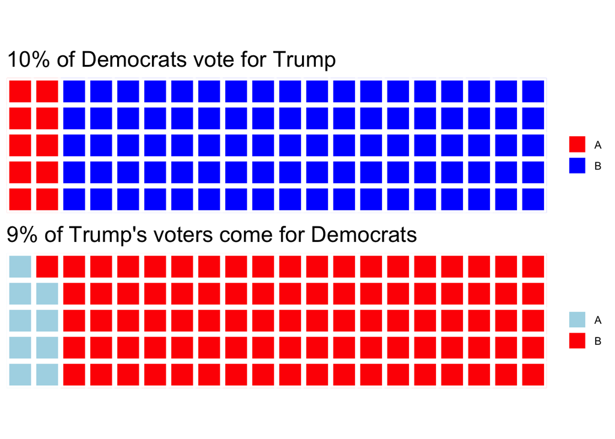

## Who are those people ?

75% of the Democratic Trump voters are under 50 and the median age for them is 40. So we have a younger Democratic Trump voters in Trump’s supporters. 60.68% of the Democratic Trump voters are male. 64.9% of them have a degree higher or equal to Bachelors. 64.1% of them have more than or equal to one child. 88.8% of them are white. Amongst those who were willing to share their income (34.1% answered), their annual income is between $75,000-$79,999 (Median household income was $68,703 in 2019). According to the definition of middle class family(those with an income that is two-thirds to double the U.S.), we can deem the 2020 Democratic Trump voters as the middle class family. Besides this, these people do not tend to trust the experts, but value the opinion of ordinary citizens. They tend to have their own judgement most of the time.

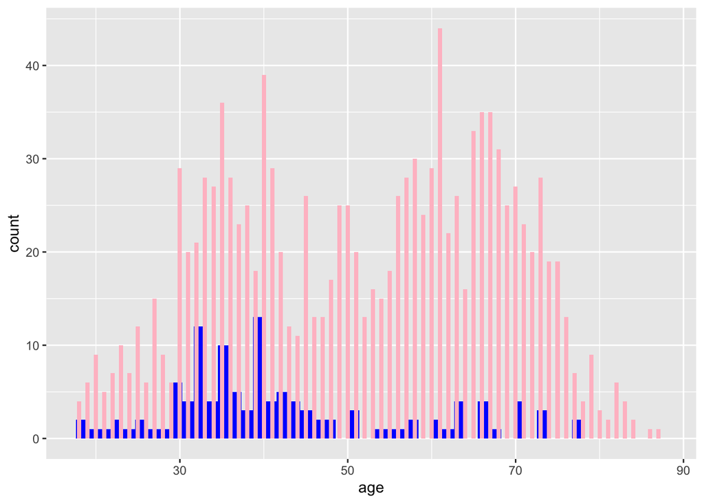

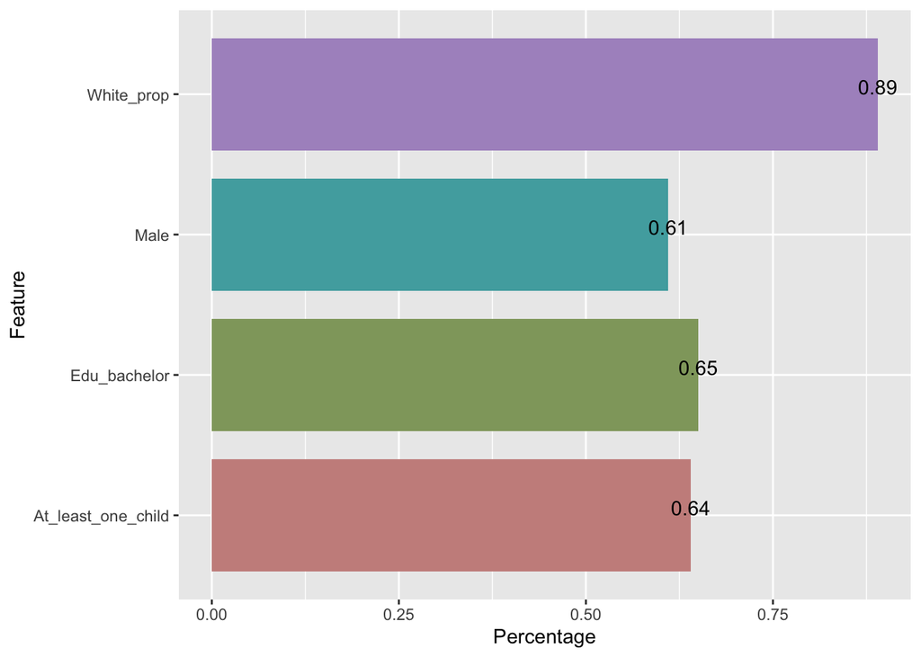

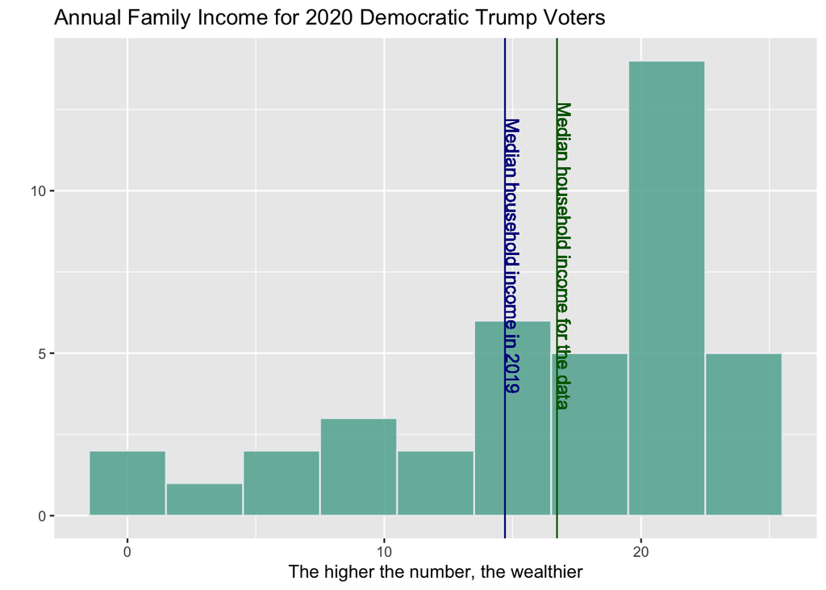

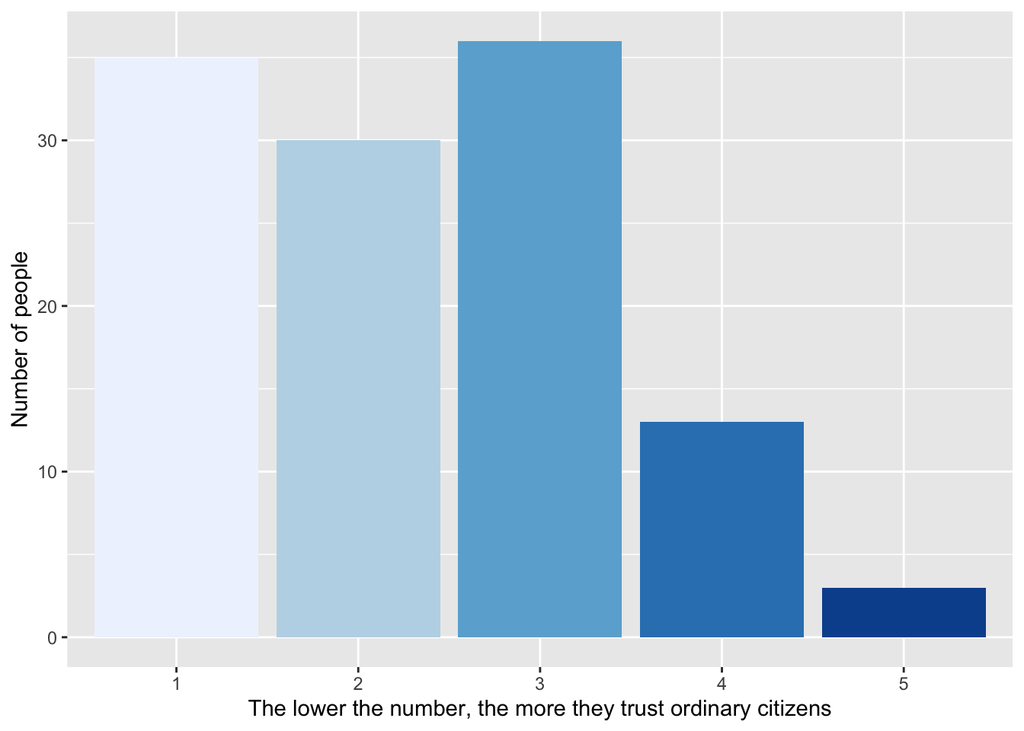

## The reasons they support Trump

### Is it because they are the Obama-Trump voters back in 2016?

Obama-Trump voters, also known as Trump Democrats or Obama Republicans, are people who voted for Democratic Party nominee Barack Obama in the 2008 or 2012 presidential elections (or both), but later voted for Republican Party nominee Donald Trump in 2016. These voters comprise 13% of Trump voters and 9% of Obama voters. In our 2020 Democratic Trump voters comprise of 9% of Trump voters and 10% of democratic. These statistics are quite similar.

According to their attitude towards Barack Obama, they are not exactly the same group of people.

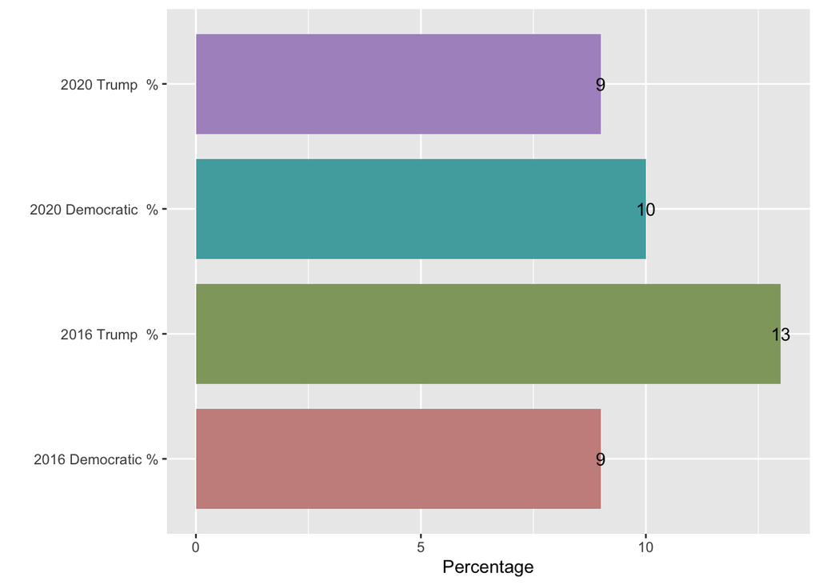

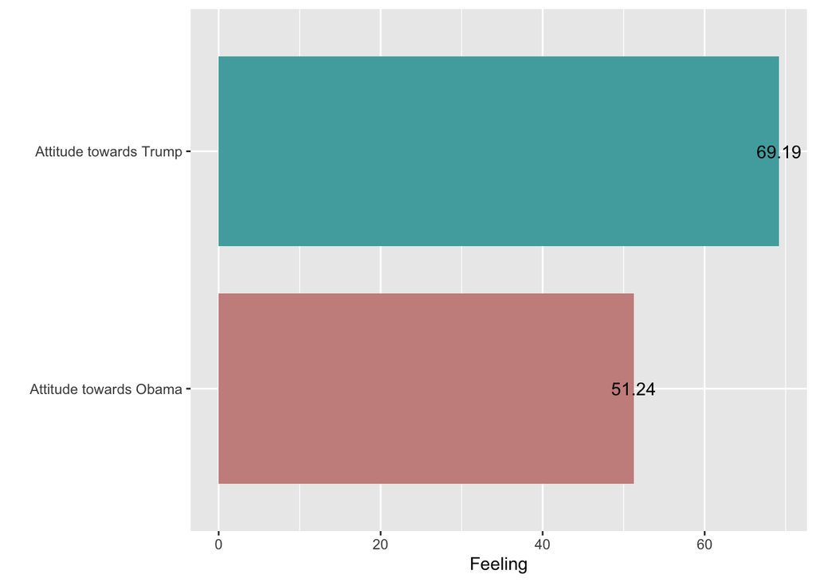

### Free market seems and Trump’s job performance are the key driving reasons for them to vote for Trump.

Although 2020 Democratic Trump and Obama-Trump voters are not very likely to be the same group of people, compared to other voters, they all tend to have liberal economic views. They expressed skepticism of congressional Republicans and a desire to change the status quo.

Most of these people approve of the way Trump handles his job and almost all of them support the free market policy. They mostly have a centrist opinion as opposed to choosing liberal or conservative.

|  | Feature | Score |
| --- | --- | --- |
| 1 | Most people attitude towards free market | 1 |
| 2 | How strong do they want free market | 1 |
| 3 | Most people attitude towards less government regulation | 1 |

|  | Feature | Score |
| --- | --- | --- |
| 1 | Approval towards Trump's job overall performance | 2.09401709401709 |
| 2 | Approval towards Trump's health care job performance | 2.6530612244898 |
| 3 | Approval towards Trump's covid job performance | 2.10294117647059 |
| 4 | Approval towards Trump's foreign relations job performance | 2.05982905982906 |

### Do they vote for Trump because they don’t like Biden?

The attitude rate towards Biden is much lower than Trump. Therefore, we can deem Democratic Trump couldn’t bring thenself to cast votes for Biden is also an important reason they vote for Trump.

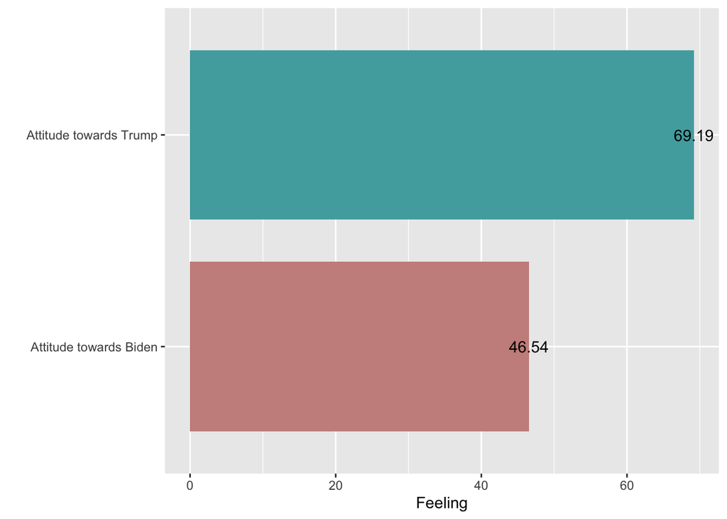

# Conclusion

## About the data and bias

Data collection was conducted between April 10, 2020 and April 18, 2020. Sample was provided by three separate opt-in internet panel vendors. ANES staff programmed the survey and collected the data directly using the Qualtrics survey platform. The combined final sample includes responses from 3,080 adult citizens from across the United State. Due to the limited size of our data, our conclusion about those who are going to vote Trump as democrats might not be holded in the total population.

## Reference

https://time.com/voices-from-democratic-counties-where-trump-won-big/